# Cluster Jerárquico en R

Un Enfoque Práctico para Aprendizaje No Supervisado

Nicolás Sidicaro

2025-06-09

# Clustering Jerárquico - Análisis Completo en R

# Basado en “An Introduction to Statistical Learning”

## Instalación y carga de librerías necesarias

```r
library(cluster)      # Para clustering
library(factoextra)   # Para visualización de clusters
library(dendextend)   # Para manipular dendrogramas
library(corrplot)     # Para matriz de correlación
library(ggplot2)      # Para gráficos
library(gridExtra)    # Para organizar gráficos
library(RColorBrewer) # Para paletas de colores
library(NbClust)      # Para determinar número óptimo de clusters
library(fpc)          # Para estadísticas de clustering
library(dplyr)        # Para manipulación de datos
library(reshape2)     # Para reestructurar datos
library(tibble)       # Para column_to_rownames
library(pheatmap)     # Para heatmaps
library(fossil)       # Para Adjusted Rand Index
```

## 1. Preparación de los Datos

Usaremos múltiples datasets para mostrar diferentes aspectos del clustering jerárquico.

```r
# Dataset 1: USArrests (datos reales con diferentes escalas)
data("USArrests")
head(USArrests)
```

|  | Murder | Assault | UrbanPop | Rape |
| --- | --- | --- | --- | --- |
| Alabama | 13.2 | 236 | 58 | 21.2 |
| Alaska | 10.0 | 263 | 48 | 44.5 |
| Arizona | 8.1 | 294 | 80 | 31.0 |
| Arkansas | 8.8 | 190 | 50 | 19.5 |
| California | 9.0 | 276 | 91 | 40.6 |
| Colorado | 7.9 | 204 | 78 | 38.7 |

```r
summary(USArrests)
```

```
##      Murder          Assault         UrbanPop          Rape
##  Min.   : 0.800   Min.   : 45.0   Min.   :32.00   Min.   : 7.30
##  1st Qu.: 4.075   1st Qu.:109.0   1st Qu.:54.50   1st Qu.:15.07
##  Median : 7.250   Median :159.0   Median :66.00   Median :20.10
##  Mean   : 7.788   Mean   :170.8   Mean   :65.54   Mean   :21.23
##  3rd Qu.:11.250   3rd Qu.:249.0   3rd Qu.:77.75   3rd Qu.:26.18
##  Max.   :17.400   Max.   :337.0   Max.   :91.00   Max.   :46.00
```

```r
# Verificar si hay valores faltantes
sum(is.na(USArrests))
```

```
## [1] 0
```

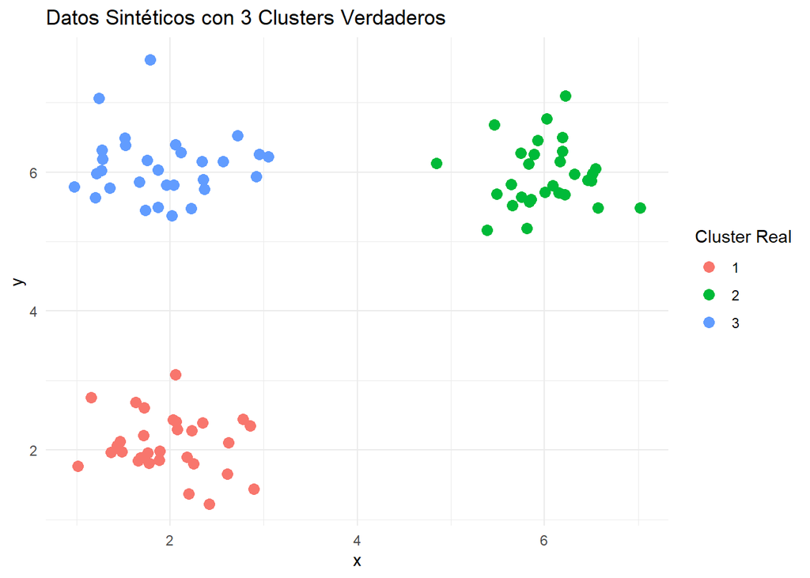

```r
# Dataset 2: Datos sintéticos para mostrar diferentes estructuras
set.seed(123)
# Crear clusters bien separados
cluster1 <- data.frame(x = rnorm(30, mean = 2, sd = 0.5),
                       y = rnorm(30, mean = 2, sd = 0.5))
cluster2 <- data.frame(x = rnorm(30, mean = 6, sd = 0.5),
                       y = rnorm(30, mean = 6, sd = 0.5))
cluster3 <- data.frame(x = rnorm(30, mean = 2, sd = 0.5),
                       y = rnorm(30, mean = 6, sd = 0.5))

synthetic_data <- rbind(cluster1, cluster2, cluster3)
synthetic_data$true_cluster <- rep(1:3, each = 30)

# Visualizar datos sintéticos
ggplot(synthetic_data, aes(x = x, y = y, color = factor(true_cluster))) +
  geom_point(size = 3) +
  labs(title = "Datos Sintéticos con 3 Clusters Verdaderos",
       color = "Cluster Real") +
  theme_minimal()
```

## 2. Escalado de Variables

**¿Qué buscar en el escalado?**

- **Antes del escalado**: Variables tienen escalas muy diferentes (UrbanPop: 32-91 vs Assault: 45-337)
- **Sin escalado**: Assault dominaría completamente las distancias
- **Después del escalado**: Todas las variables tienen media=0 y sd=1
- **Resultado**: Cada variable contribuye equitativamente a las distancias
- **Recomendación**: SIEMPRE escalar cuando las unidades son diferentes

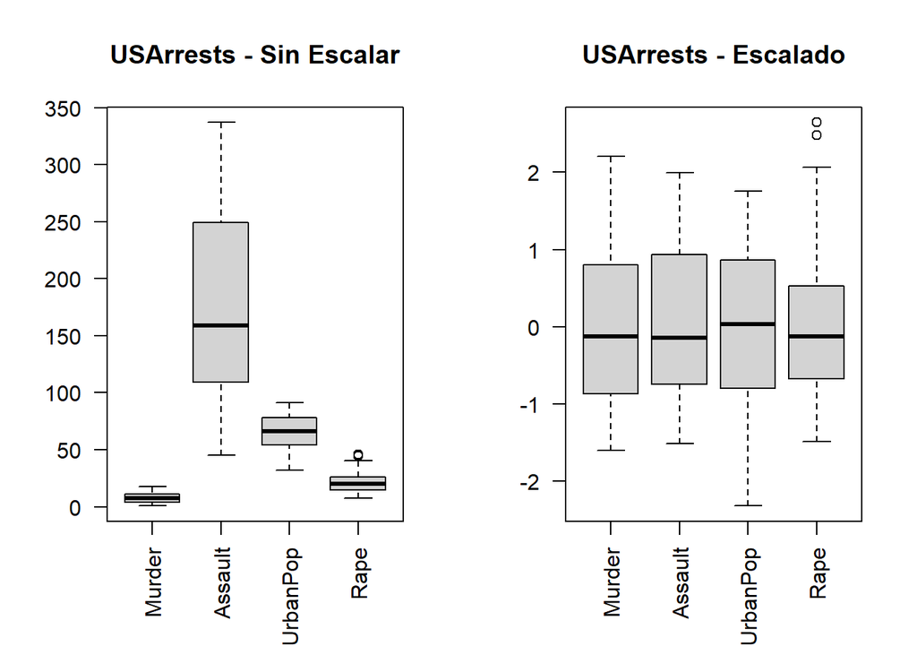

```
## Medias después del escalado:
```

```
##   Murder  Assault UrbanPop     Rape
##        0        0        0        0
```

```
##
## Desviaciones estándar después del escalado:
```

```
##   Murder  Assault UrbanPop     Rape
##        1        1        1        1
```

```r
# Importancia del escalado - Comparación con y sin escalar
par(mfrow = c(1, 2))

# Sin escalar
boxplot(USArrests, main = "USArrests - Sin Escalar", las = 2)

# Escalado (estandarización)
USArrests_scaled <- scale(USArrests)
boxplot(USArrests_scaled, main = "USArrests - Escalado", las = 2)
```

## 3. Diferentes Medidas de Distancia

**¿Qué buscar en las distancias?**

- **Colores en heatmap**: Rojo = mayor distancia (más diferentes), Blanco = menor distancia (más similares)
- **Euclidiana**: Distancia ‘en línea recta’, sensible a outliers
- **Manhattan**: Suma diferencias absolutas, más robusta a outliers
- **Correlación**: Mide patrones similares, no magnitudes
- **Comparación**: Si los valores son muy diferentes entre métodos, indica que la elección de distancia SÍ importa

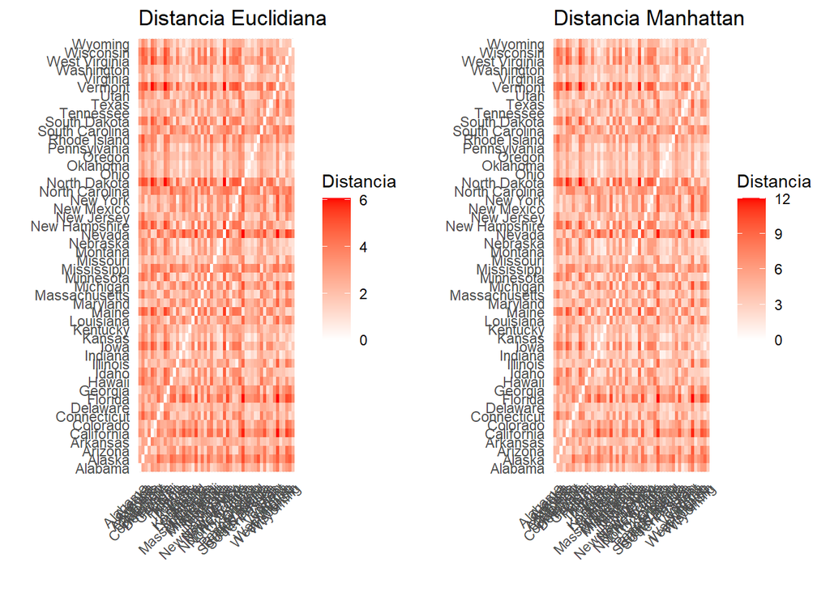

```
## Comparación de distancias entre estados seleccionados:
```

```
## Euclidiana vs Manhattan para California-Texas:
```

```
## Euclidiana: 2.17
```

```
## Manhattan: 4.122
```

```r
# Calcular diferentes matrices de distancia
dist_euclidean <- dist(USArrests_scaled, method = "euclidean")
dist_manhattan <- dist(USArrests_scaled, method = "manhattan")
dist_maximum <- dist(USArrests_scaled, method = "maximum")

# Para distancia de correlación, necesitamos transponer
dist_correlation <- as.dist(1 - cor(t(USArrests_scaled)))

# Función para visualizar matriz de distancias
plot_distance_matrix <- function(dist_matrix, title) {
  dist_df <- as.matrix(dist_matrix)
  melted_dist <- melt(dist_df)

  ggplot(melted_dist, aes(Var1, Var2, fill = value)) +
    geom_tile() +
    scale_fill_gradient(low = "white", high = "red") +
    theme_minimal() +
    theme(axis.text.x = element_text(angle = 45, hjust = 1)) +
    labs(title = title, x = "", y = "", fill = "Distancia")
}

# Visualizar las diferentes matrices de distancia
p1 <- plot_distance_matrix(dist_euclidean, "Distancia Euclidiana")
p2 <- plot_distance_matrix(dist_manhattan, "Distancia Manhattan")

grid.arrange(p1, p2, ncol = 2)
```

## 4. Diferentes Métodos de Enlace (Linkage)

**¿Qué buscar en los dendrogramas?**

- **Altura**: Distancia a la cual se fusionan clusters (mayor altura = clusters más diferentes al fusionarse)
- **Forma del árbol**:
  - **COMPLETE**: Clusters compactos, alturas bien diferenciadas
  - **SINGLE**: Tiende a crear ‘cadenas’, sensible a outliers
  - **WARD**: Clusters balanceados, minimiza varianza intra-cluster
  - **AVERAGE**: Compromiso entre Complete y Single
- **Rectángulos**: Muestran los k=4 clusters seleccionados
- **Comparar**: ¿Qué método produce clusters más interpretables? ¿Los grupos tienen sentido conceptual?

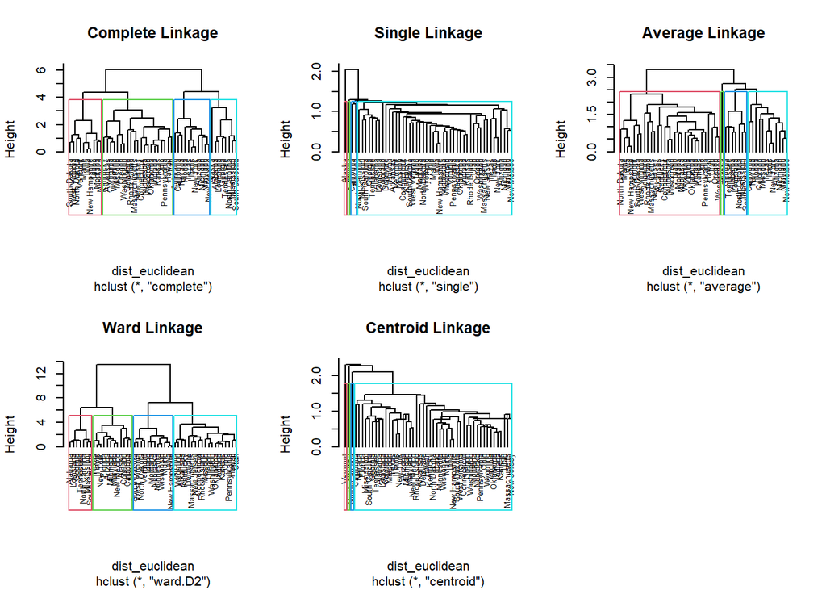

```r
# Aplicar diferentes métodos de enlace
hc_complete <- hclust(dist_euclidean, method = "complete")
hc_single <- hclust(dist_euclidean, method = "single")
hc_average <- hclust(dist_euclidean, method = "average")
hc_ward <- hclust(dist_euclidean, method = "ward.D2")
hc_centroid <- hclust(dist_euclidean, method = "centroid")

# Función para plotear dendrogramas
plot_dendrogram <- function(hc_object, title, k = 4) {
  plot(hc_object, main = title, cex = 0.6, hang = -1)
  rect.hclust(hc_object, k = k, border = 2:5)
}

# Crear gráficos de dendrogramas
par(mfrow = c(2, 3))
plot_dendrogram(hc_complete, "Complete Linkage")
plot_dendrogram(hc_single, "Single Linkage")
plot_dendrogram(hc_average, "Average Linkage")
plot_dendrogram(hc_ward, "Ward Linkage")
plot_dendrogram(hc_centroid, "Centroid Linkage")

# Resetear parámetros gráficos
par(mfrow = c(1, 1))
```

## 5. Métodos para Determinar el Número Óptimo de Clusters

### 5.1 Método del Codo (Elbow Method)

**¿Qué buscar en el método del codo?**

- **Objetivo**: Encontrar el ‘codo’ donde la mejora marginal se vuelve pequeña
- **WCSS**: Within Cluster Sum of Squares - menor es mejor
- **Forma ideal**: Curva que baja rápido y luego se aplana
- **Buscar**: El punto donde la curva cambia de pendiente pronunciada a suave
- **Limitación**: A veces el codo no es obvio - método subjetivo

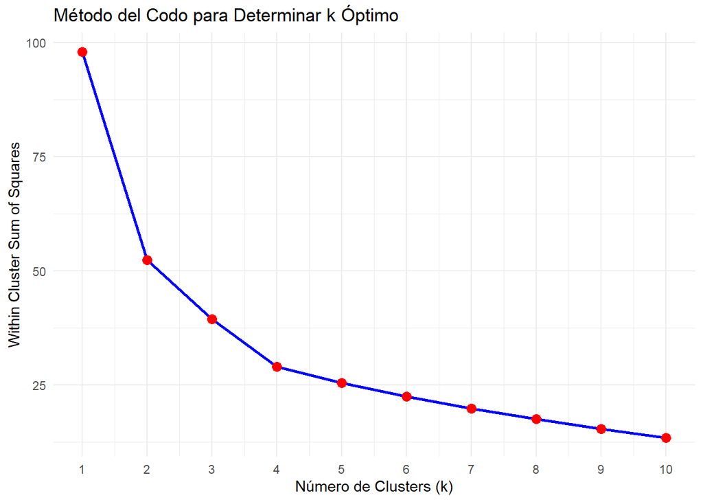

```r
# Función para calcular WCSS (Within Cluster Sum of Squares)
calculate_wcss <- function(data, max_k = 10, method = "ward.D2") {
  wcss <- numeric(max_k)

  for(k in 1:max_k) {
    # Clustering jerárquico
    hc <- hclust(dist(data), method = method)
    clusters <- cutree(hc, k = k)

    # Calcular WCSS
    wcss[k] <- sum(sapply(1:k, function(i) {
      cluster_data <- data[clusters == i, , drop = FALSE]
      if(nrow(cluster_data) > 1) {
        sum(dist(cluster_data)^2) / (2 * nrow(cluster_data))
      } else {
        0
      }
    }))
  }

  return(wcss)
}

# Calcular WCSS para diferentes números de clusters
wcss_values <- calculate_wcss(USArrests_scaled, max_k = 10)

# Plotear método del codo
elbow_data <- data.frame(k = 1:10, wcss = wcss_values)
ggplot(elbow_data, aes(x = k, y = wcss)) +
  geom_line(size = 1, color = "blue") +
  geom_point(size = 3, color = "red") +
  scale_x_continuous(breaks = 1:10) +
  labs(title = "Método del Codo para Determinar k Óptimo",
       x = "Número de Clusters (k)",
       y = "Within Cluster Sum of Squares") +
  theme_minimal()
```

```r
# Encontrar el codo aproximado
diff1 <- diff(wcss_values)
diff2 <- diff(diff1)
suggested_k_elbow <- which.max(diff2) + 1
```

```
## Sugerencia del método del codo: k = 2
```

### 5.2 Gap Statistic

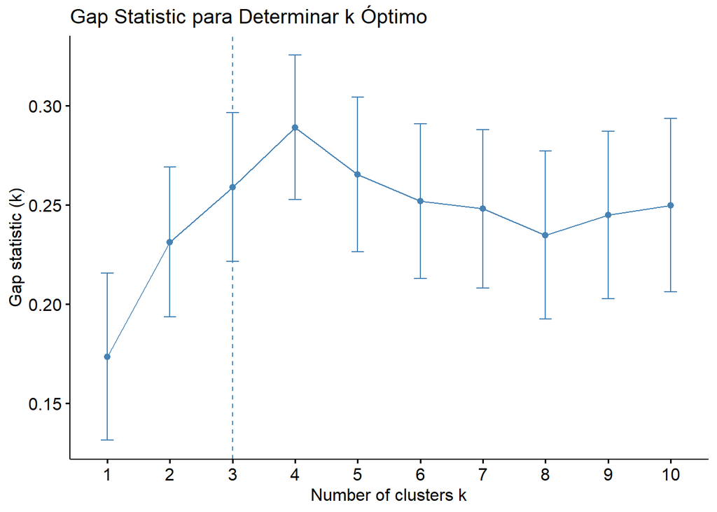

```r
# Calcular Gap Statistic
gap_stat <- clusGap(USArrests_scaled,
                    FUN = function(x, k) {
                      hc <- hclust(dist(x), method = "ward.D2")
                      list(cluster = cutree(hc, k = k))
                    },
                    K.max = 10,
                    B = 50)  # 50 simulaciones

# Plotear Gap Statistic
fviz_gap_stat(gap_stat) +
  labs(title = "Gap Statistic para Determinar k Óptimo")
```

```r
# Imprimir resultados
print(gap_stat, method = "firstmax")
```

```
## Clustering Gap statistic ["clusGap"] from call:
## clusGap(x = USArrests_scaled, FUNcluster = function(x, k) {     hc <- hclust(dist(x), method = "ward.D2")     list(cluster = cutree(hc, k = k)) }, K.max = 10, B = 50)
## B=50 simulated reference sets, k = 1..10; spaceH0="scaledPCA"
##  --> Number of clusters (method 'firstmax'): 4
##           logW   E.logW       gap     SE.sim
##  [1,] 3.458369 3.631780 0.1734110 0.04208754
##  [2,] 3.142869 3.374184 0.2313149 0.03780295
##  [3,] 2.978518 3.237524 0.2590066 0.03752715
##  [4,] 2.833430 3.122590 0.2891607 0.03633648
##  [5,] 2.759739 3.025110 0.2653716 0.03893419
##  [6,] 2.689377 2.941223 0.2518460 0.03906497
##  [7,] 2.616505 2.864583 0.2480783 0.03998770
##  [8,] 2.556388 2.791152 0.2347635 0.04234678
##  [9,] 2.478796 2.723726 0.2449297 0.04219190
## [10,] 2.408612 2.658493 0.2498812 0.04381286
```

### 5.3 Silhouette Analysis

**¿Qué buscar en el Silhouette Analysis?**

- **Silhouette Width**: Mide qué tan bien asignado está cada punto (rango: -1 a +1)
  - Cerca de +1: Punto bien asignado a su cluster
  - Cerca de 0: Punto está en la frontera entre clusters
  - Cerca de -1: Punto probablemente mal asignado
- **Interpretación de promedios**:
  - 0.71-1.00: Estructura fuerte
  - 0.51-0.70: Estructura razonable
  - 0.26-0.50: Estructura débil
  - < 0.25: Sin estructura sustancial
- **Buscar**: El k que maximice el Average Silhouette Width

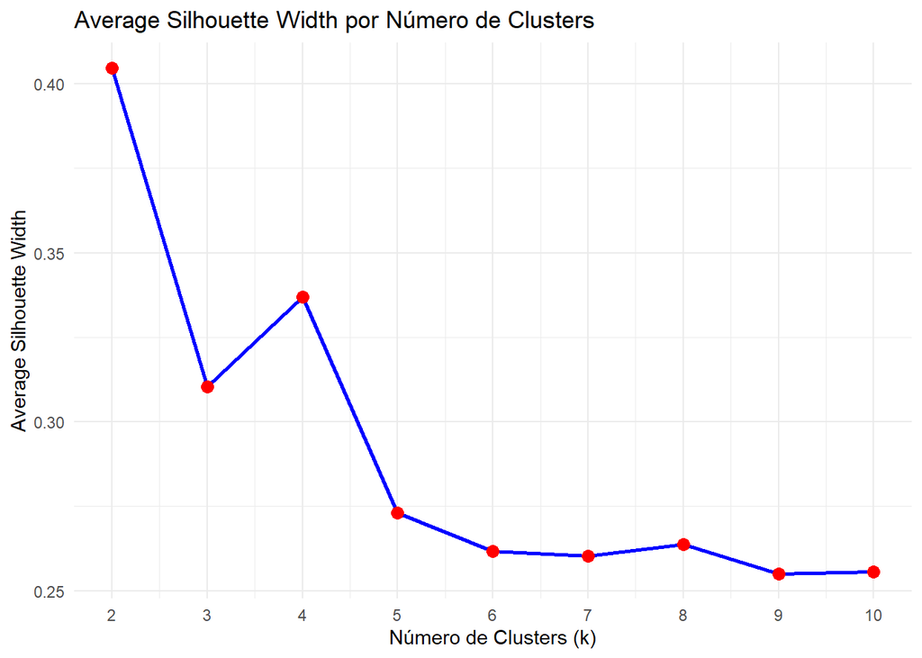

```r
# Función para calcular average silhouette width
calc_silhouette <- function(data, max_k = 10, method = "ward.D2") {
  sil_width <- numeric(max_k - 1)

  for(k in 2:max_k) {
    hc <- hclust(dist(data), method = method)
    clusters <- cutree(hc, k = k)
    sil <- silhouette(clusters, dist(data))
    sil_width[k-1] <- mean(sil[, 3])
  }

  return(sil_width)
}

# Calcular silhouette widths
sil_widths <- calc_silhouette(USArrests_scaled, max_k = 10)

# Plotear
sil_data <- data.frame(k = 2:10, avg_sil = sil_widths)
ggplot(sil_data, aes(x = k, y = avg_sil)) +
  geom_line(size = 1, color = "blue") +
  geom_point(size = 3, color = "red") +
  scale_x_continuous(breaks = 2:10) +
  labs(title = "Average Silhouette Width por Número de Clusters",
       x = "Número de Clusters (k)",
       y = "Average Silhouette Width") +
  theme_minimal()
```

```r
# Encontrar k óptimo
optimal_k_sil <- which.max(sil_widths) + 1
```

```
## Número óptimo de clusters según Silhouette: 2
```

```
## Valor de Silhouette Width: 0.405
```

### 5.4 NbClust - Múltiples Criterios

```r
# Usar NbClust para múltiples criterios
nb_clust_result <- NbClust(USArrests_scaled,
                          distance = "euclidean",
                          min.nc = 2, max.nc = 10,
                          method = "ward.D2",
                          index = "all")
```

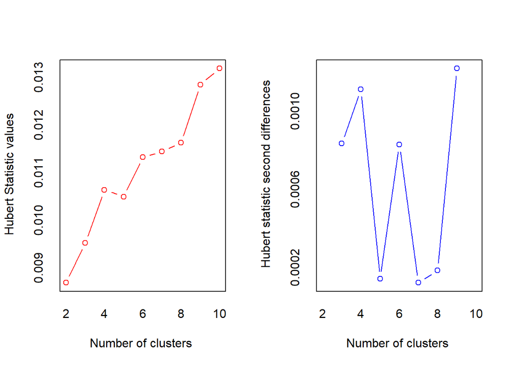

```
## *** : The Hubert index is a graphical method of determining the number of clusters.
##                 In the plot of Hubert index, we seek a significant knee that corresponds to a
##                 significant increase of the value of the measure i.e the significant peak in Hubert
##                 index second differences plot.
##
```

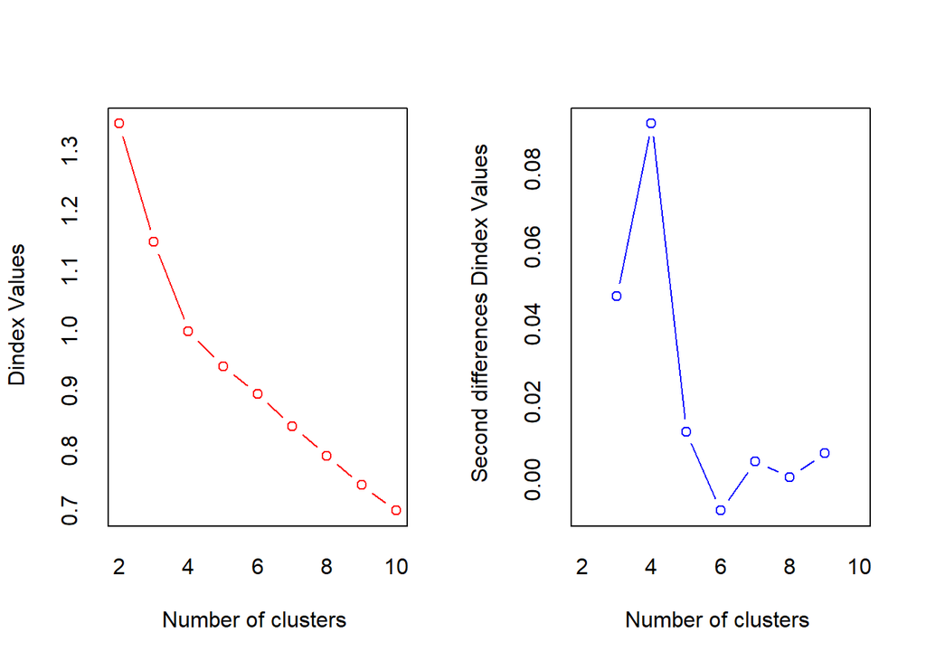

```
## *** : The D index is a graphical method of determining the number of clusters.
##                 In the plot of D index, we seek a significant knee (the significant peak in Dindex
##                 second differences plot) that corresponds to a significant increase of the value of
##                 the measure.
##
## * Among all indices:
## * 10 proposed 2 as the best number of clusters
## * 3 proposed 3 as the best number of clusters
## * 8 proposed 4 as the best number of clusters
## * 1 proposed 7 as the best number of clusters
## * 2 proposed 10 as the best number of clusters
##
##                    ***** Conclusion *****
##
## * According to the majority rule, the best number of clusters is  2
##
##
```

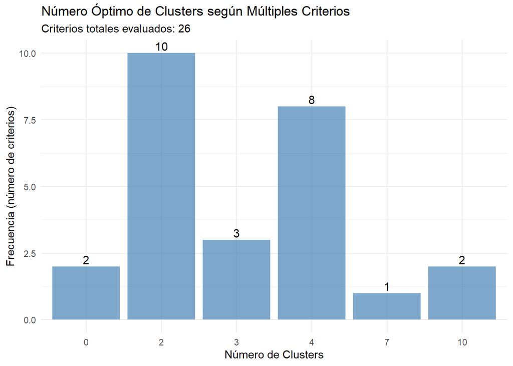

```r
# Crear visualización manual de los resultados de NbClust
# Extraer el número de clusters sugerido por cada criterio
best_nc_table <- table(nb_clust_result$Best.nc[1,])
best_nc_df <- data.frame(
  clusters = as.numeric(names(best_nc_table)),
  frequency = as.numeric(best_nc_table)
)

# Plotear resultados
ggplot(best_nc_df, aes(x = factor(clusters), y = frequency)) +
  geom_bar(stat = "identity", fill = "steelblue", alpha = 0.7) +
  geom_text(aes(label = frequency), vjust = -0.3, size = 4) +
  labs(title = "Número Óptimo de Clusters según Múltiples Criterios",
       subtitle = paste("Criterios totales evaluados:", length(nb_clust_result$Best.nc[1,])),
       x = "Número de Clusters",
       y = "Frecuencia (número de criterios)") +
  theme_minimal()
```

```r
# Mostrar resumen
cat("Resumen de NbClust:\n")
```

```
## Resumen de NbClust:
```

```r
cat("Número de clusters más frecuentemente sugerido:",
    names(sort(best_nc_table, decreasing = TRUE))[1], "\n")
```

```
## Número de clusters más frecuentemente sugerido: 2
```

```r
cat("Criterios que lo sugieren:", max(best_nc_table), "de",
    length(nb_clust_result$Best.nc[1,]), "\n\n")
```

```
## Criterios que lo sugieren: 10 de 26
```

```r
# Mostrar algunos criterios específicos
if("Best.nc" %in% names(nb_clust_result)) {
  cat("Algunos criterios individuales:\n")
  criterios_importantes <- c("KL", "CH", "Hartigan", "CCC", "Scott", "Marriot", "TrCovW", "TraceW")
  for(criterio in criterios_importantes) {
    if(criterio %in% colnames(nb_clust_result$Best.nc)) {
      cat(criterio, ":", nb_clust_result$Best.nc[1, criterio], "clusters\n")
    }
  }
}
```

```
## Algunos criterios individuales:
## KL : 4 clusters
## CH : 2 clusters
## Hartigan : 4 clusters
## CCC : 4 clusters
## Scott : 3 clusters
## Marriot : 4 clusters
## TrCovW : 4 clusters
## TraceW : 4 clusters
```

## 6. Comparación de Resultados con Diferentes Métodos

**¿Qué buscar en la comparación de métodos?**

- **Adjusted Rand Index (ARI)**: Mide similitud entre dos clusterings
- ARI = 1: Clusterings idénticos
- ARI = 0: Similitud igual al azar
- ARI < 0: Similitud peor que el azar
- **Interpretación ARI**: 0.90-1.00 (casi idénticos), 0.80-0.90 (muy similares), 0.65-0.80 (moderadamente similares), < 0.65 (diferentes)
- **Matriz de confusión**: Muestra cómo se redistribuyen los puntos
- **Si ARI es bajo**: Los métodos producen resultados MUY diferentes - necesitas decidir cuál tiene más sentido teórico

```r
# Aplicar clustering con k=4 usando diferentes métodos de enlace
k_optimal <- 4

clusters_complete <- cutree(hc_complete, k = k_optimal)
clusters_single <- cutree(hc_single, k = k_optimal)
clusters_average <- cutree(hc_average, k = k_optimal)
clusters_ward <- cutree(hc_ward, k = k_optimal)

# Crear dataframe con resultados
comparison_df <- data.frame(
  State = rownames(USArrests),
  Complete = clusters_complete,
  Single = clusters_single,
  Average = clusters_average,
  Ward = clusters_ward
)

# Mostrar primeras filas
head(comparison_df, 10)
```

|  | State | Complete | Single | Average | Ward |
| --- | --- | --- | --- | --- | --- |
| Alabama | Alabama | 1 | 1 | 1 | 1 |
| Alaska | Alaska | 1 | 2 | 2 | 2 |
| Arizona | Arizona | 2 | 1 | 3 | 2 |
| Arkansas | Arkansas | 3 | 1 | 4 | 3 |
| California | California | 2 | 3 | 3 | 2 |
| Colorado | Colorado | 2 | 1 | 3 | 2 |
| Connecticut | Connecticut | 3 | 1 | 4 | 3 |
| Delaware | Delaware | 3 | 1 | 4 | 3 |
| Florida | Florida | 2 | 4 | 3 | 2 |
| Georgia | Georgia | 1 | 1 | 1 | 1 |

```r
# Adjusted Rand Index para comparar similitud entre métodos
ari_complete_ward <- fossil::adj.rand.index(clusters_complete, clusters_ward)
ari_complete_single <- fossil::adj.rand.index(clusters_complete, clusters_single)
```

```
## Matriz de confusión: Complete vs Ward
```

```
##                  clusters_ward
## clusters_complete  1  2  3  4
##                 1  7  1  0  0
##                 2  0 11  0  0
##                 3  0  0 19  2
##                 4  0  0  0 10
```

```
##
## Matriz de confusión: Complete vs Single
```

```
##                  clusters_single
## clusters_complete  1  2  3  4
##                 1  7  1  0  0
##                 2  8  0  2  1
##                 3 21  0  0  0
##                 4 10  0  0  0
```

```
##
## Adjusted Rand Index (Complete vs Ward): 0.843
```

```
## Adjusted Rand Index (Complete vs Single): 0.048
```

## 7. Análisis de Calidad de Clustering

**¿Qué buscar en el análisis de calidad?**

**Silhouette Plot Detallado:**

- Cada barra = un estado, ordenados por cluster y valor silhouette
- Barras rojas/negativas: Estados mal asignados
- Ancho promedio por cluster: ¿Hay clusters internamente cohesivos?
- Clusters con muchas barras rojas: Problemas de asignación

**Dunn Index:** Cociente entre menor distancia inter-cluster y mayor intra-cluster

- Valores más altos = mejor separación
- > 0.1 se considera aceptable

**Estadísticas por Cluster:**

- ¿Los clusters tienen interpretación sustantiva?
- ¿Las medias por cluster son distintivas?
- ¿Los tamaños de cluster son razonables?
- **Coherencia**: Los clusters deben tener sentido en el dominio del problema

```
##   cluster size ave.sil.width
## 1       1    7          0.46
## 2       2   12          0.29
## 3       3   19          0.26
## 4       4   12          0.43
```

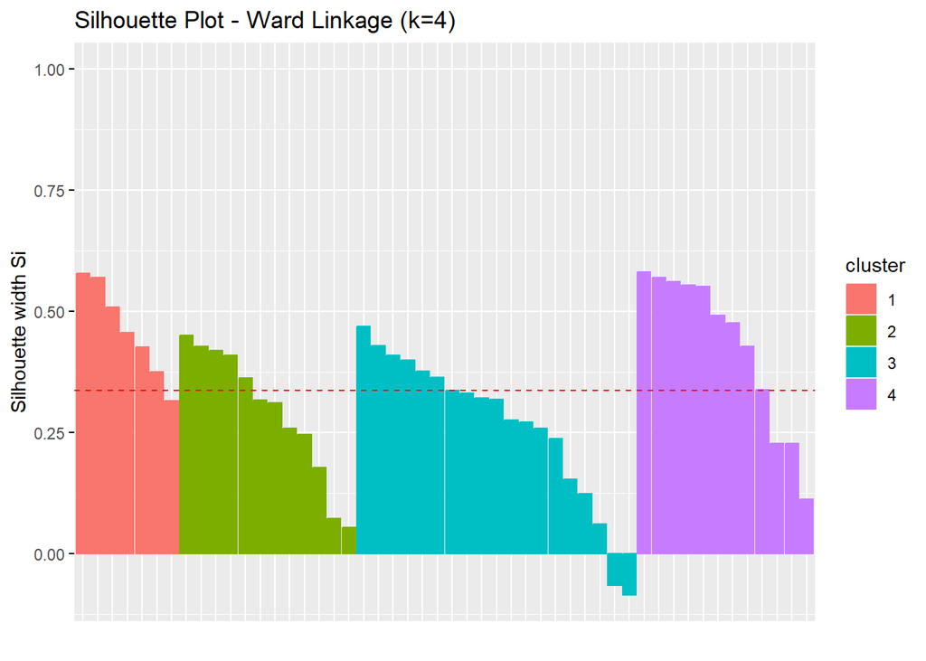

```r
# Usar clustering Ward (generalmente da buenos resultados)
final_clusters <- cutree(hc_ward, k = k_optimal)

# Silhouette plot detallado
sil_ward <- silhouette(final_clusters, dist_euclidean)
fviz_silhouette(sil_ward) +
  labs(title = "Silhouette Plot - Ward Linkage (k=4)")
```

```r
# Estadísticas de clustering
cluster_stats <- cluster.stats(dist_euclidean, final_clusters)

# Función auxiliar para verificar y redondear valores
safe_round <- function(value, digits = 3) {
  if(is.null(value) || !is.numeric(value) || is.na(value)) {
    return("No disponible")
  } else {
    return(round(value, digits))
  }
}

# Estadísticas de clustering
cluster_stats <- cluster.stats(dist_euclidean, final_clusters)

# Función auxiliar para verificar y redondear valores
safe_round <- function(value, digits = 3) {
  if(is.null(value) || !is.numeric(value) || is.na(value)) {
    return("No disponible")
  } else {
    return(round(value, digits))
  }
}
```

```
## Estadísticas de Clustering (Ward, k=4):
```

```
## Average Silhouette Width: 0.337
```

```
## Dunn Index: 0.16
```

```
## Within Sum of Squares: 57.943
```

```
## Between Sum of Squares: No disponible
```

```
## Número de clusters: 4
```

```
## Número de observaciones: 50
```

```r
# Análisis por cluster
USArrests_clustered <- USArrests_scaled
USArrests_clustered <- data.frame(USArrests_clustered)
USArrests_clustered$Cluster <- final_clusters

# Estadísticas por cluster
cluster_summary <- USArrests_clustered %>%
  group_by(Cluster) %>%
  summarise(
    n = n(),
    Murder_mean = round(mean(Murder), 2),
    Assault_mean = round(mean(Assault), 2),
    UrbanPop_mean = round(mean(UrbanPop), 2),
    Rape_mean = round(mean(Rape), 2),
    .groups = 'drop'
  )

print(cluster_summary)
```

```
## # A tibble: 4 × 6
##   Cluster     n Murder_mean Assault_mean UrbanPop_mean Rape_mean
##     <int> <int>       <dbl>        <dbl>         <dbl>     <dbl>
## 1       1     7        1.58         0.97         -0.78      0.05
## 2       2    12        0.73         1.12          0.76      1.32
## 3       3    19       -0.36        -0.34          0.4      -0.22
## 4       4    12       -1.08        -1.14         -0.93     -1
```

## 8. Visualización de Resultados

**¿Qué buscar en las visualizaciones?**

**Gráfico PCA:**

- Proyección de datos 4D en 2D para visualización
- % en ejes: proporción de varianza explicada por cada PC
- **Clusters bien separados**: Buenos resultados de clustering
- **Clusters superpuestos**: Puede indicar sobre-segmentación
- **Outliers visibles**: Estados que no encajan bien en ningún cluster

**Heatmap de Perfiles:**

- Muestra características promedio de cada cluster
- **Colores**: Azul = bajo, Blanco = promedio, Rojo = alto
- **Buscar**: Patrones distintivos por cluster
- **Interpretabilidad**: ¿Los perfiles tienen sentido conceptual?

**Validación Visual:**

- ¿Los clusters se ven naturales en PCA?
- ¿Los perfiles son distintivos y coherentes?
- ¿Estados similares están en el mismo cluster?

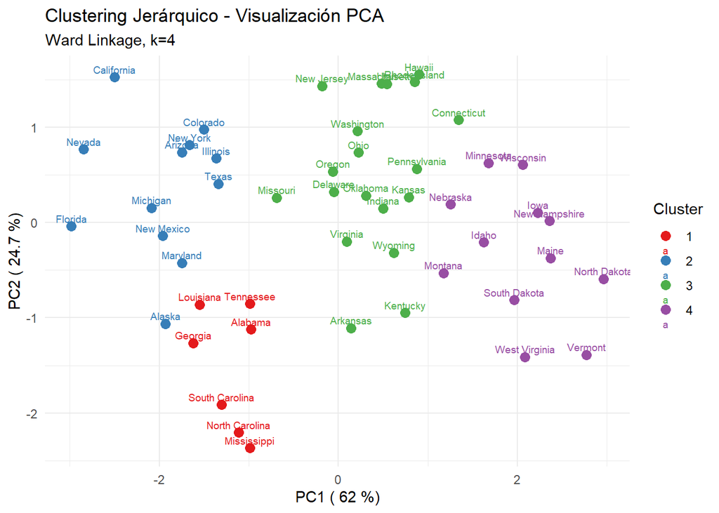

```r
# PCA para visualización en 2D
pca_result <- prcomp(USArrests_scaled)
pca_data <- data.frame(pca_result$x[, 1:2])
pca_data$Cluster <- factor(final_clusters)
pca_data$State <- rownames(USArrests)

# Plot PCA con clusters
ggplot(pca_data, aes(x = PC1, y = PC2, color = Cluster)) +
  geom_point(size = 3) +
  geom_text(aes(label = State), vjust = -0.5, size = 2.5) +
  labs(title = "Clustering Jerárquico - Visualización PCA",
       subtitle = "Ward Linkage, k=4",
       x = paste("PC1 (", round(summary(pca_result)$importance[2,1] * 100, 1), "%)"),
       y = paste("PC2 (", round(summary(pca_result)$importance[2,2] * 100, 1), "%)")) +
  theme_minimal() +
  scale_color_brewer(type = "qual", palette = "Set1")
```

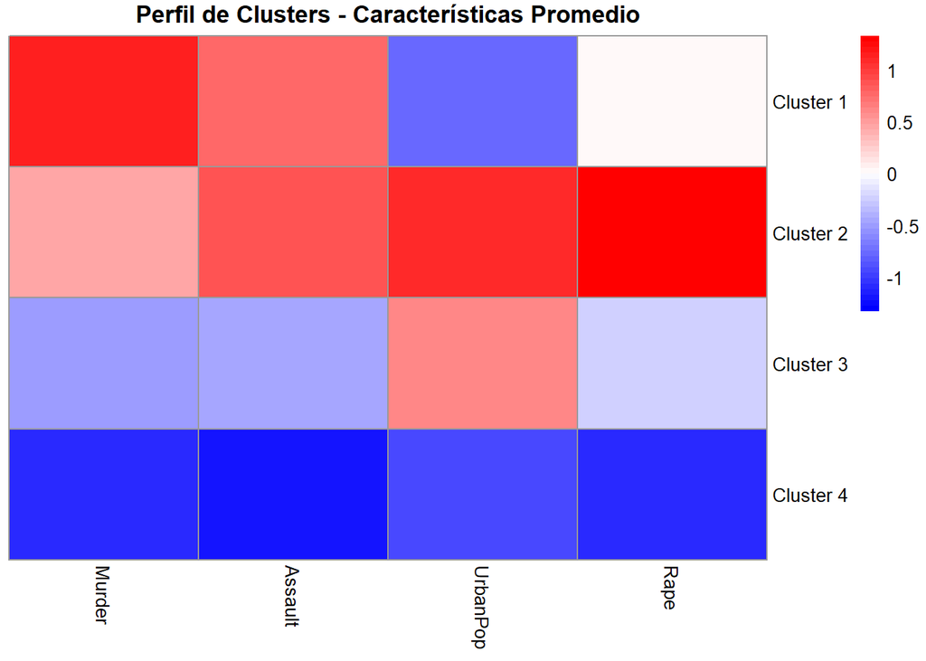

```r
# Heatmap de características por cluster
USArrests_means <- USArrests_clustered %>%
  group_by(Cluster) %>%
  summarise_all(mean, na.rm = TRUE)

# Convertir a matriz con nombres de fila (método base R)
USArrests_means_matrix <- as.matrix(USArrests_means[, -1])  # Excluir columna Cluster
rownames(USArrests_means_matrix) <- paste("Cluster", USArrests_means$Cluster)

# Crear heatmap
pheatmap::pheatmap(USArrests_means_matrix,
                   scale = "column",
                   cluster_rows = FALSE,
                   cluster_cols = FALSE,
                   main = "Perfil de Clusters - Características Promedio",
                   color = colorRampPalette(c("blue", "white", "red"))(50))
```

## 9. Comparación con Diferentes Distancias

**¿Qué buscar en la comparación de distancias?**

- **ARI entre distancias**: Valores altos indican que la elección de distancia no afecta mucho
- **ARI bajos**: Significan que la distancia elegida SÍ importa para estos datos
- **Consistencia**: Si los resultados son muy diferentes, evaluar cuál tiene más sentido teórico

```r
# Aplicar clustering con diferentes distancias
hc_euclidean <- hclust(dist_euclidean, method = "ward.D2")
hc_manhattan <- hclust(dist_manhattan, method = "ward.D2")
hc_correlation <- hclust(dist_correlation, method = "ward.D2")

# Obtener clusters
clusters_euclidean <- cutree(hc_euclidean, k = 4)
clusters_manhattan <- cutree(hc_manhattan, k = 4)
clusters_correlation <- cutree(hc_correlation, k = 4)

# Comparar resultados
distance_comparison <- data.frame(
  State = rownames(USArrests),
  Euclidean = clusters_euclidean,
  Manhattan = clusters_manhattan,
  Correlation = clusters_correlation
)

head(distance_comparison, 10)
```

|  | State | Euclidean | Manhattan | Correlation |
| --- | --- | --- | --- | --- |
| Alabama | Alabama | 1 | 1 | 1 |
| Alaska | Alaska | 2 | 2 | 1 |
| Arizona | Arizona | 2 | 2 | 2 |
| Arkansas | Arkansas | 3 | 3 | 1 |
| California | California | 2 | 2 | 2 |
| Colorado | Colorado | 2 | 2 | 2 |
| Connecticut | Connecticut | 3 | 3 | 3 |
| Delaware | Delaware | 3 | 3 | 4 |
| Florida | Florida | 2 | 2 | 1 |
| Georgia | Georgia | 1 | 1 | 1 |

```r
# ARI entre diferentes distancias
ari_euc_man <- fossil::adj.rand.index(clusters_euclidean, clusters_manhattan)
ari_euc_cor <- fossil::adj.rand.index(clusters_euclidean, clusters_correlation)
ari_man_cor <- fossil::adj.rand.index(clusters_manhattan, clusters_correlation)
```

```
## Comparación de métodos de distancia (ARI):
```

```
## Euclidean vs Manhattan: 0.829
```

```
## Euclidean vs Correlation: 0.064
```

```
## Manhattan vs Correlation: 0.064
```

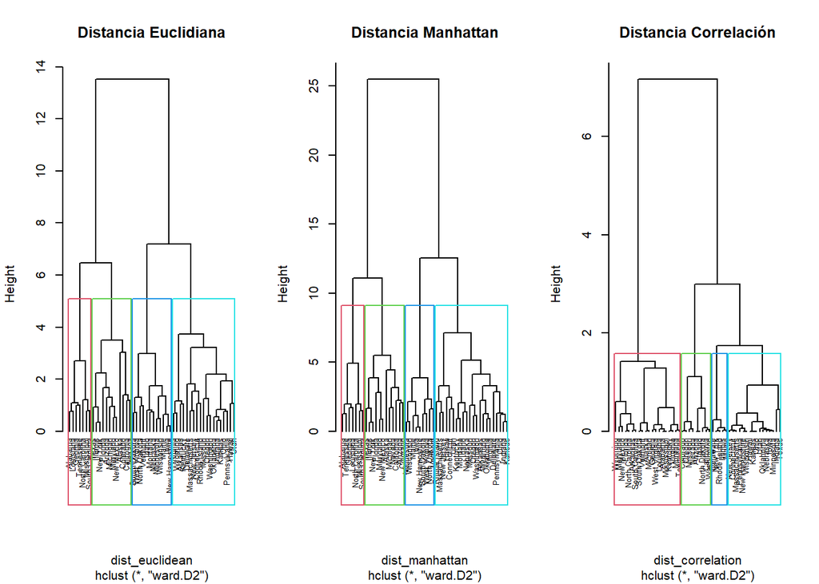

```r
# Visualizar dendrogramas lado a lado
par(mfrow = c(1, 3))
plot(hc_euclidean, main = "Distancia Euclidiana", cex = 0.6, hang = -1)
rect.hclust(hc_euclidean, k = 4, border = 2:5)

plot(hc_manhattan, main = "Distancia Manhattan", cex = 0.6, hang = -1)
rect.hclust(hc_manhattan, k = 4, border = 2:5)

plot(hc_correlation, main = "Distancia Correlación", cex = 0.6, hang = -1)
rect.hclust(hc_correlation, k = 4, border = 2:5)
```

```r
par(mfrow = c(1, 1))
```

## 10. Aplicación en Datos Sintéticos

**¿Qué buscar en datos sintéticos?**

- **Ventaja**: Conocemos la “verdad” - podemos evaluar qué tan bien funciona el algoritmo
- **ARI alto**: El algoritmo recuperó correctamente la estructura conocida
- **Matriz de confusión**: Muestra exactamente qué puntos se asignaron incorrectamente
- **Gap statistic**: Debería sugerir el número correcto de clusters (k=3)

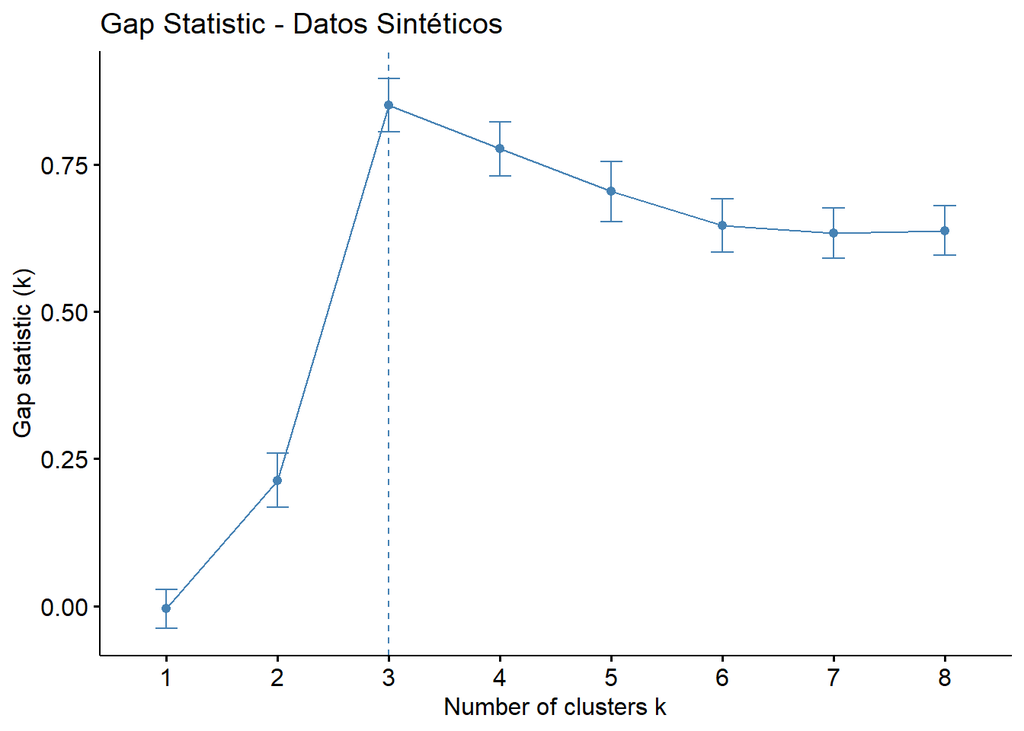

```r
# Aplicar clustering jerárquico a datos sintéticos
synthetic_matrix <- as.matrix(synthetic_data[, 1:2])
dist_synthetic <- dist(synthetic_matrix)
hc_synthetic <- hclust(dist_synthetic, method = "ward.D2")

# Determinar número óptimo de clusters
gap_synthetic <- clusGap(synthetic_matrix,
                        FUN = function(x, k) {
                          hc <- hclust(dist(x), method = "ward.D2")
                          list(cluster = cutree(hc, k = k))
                        },
                        K.max = 8, B = 20)

# Plot gap statistic
fviz_gap_stat(gap_synthetic) +
  labs(title = "Gap Statistic - Datos Sintéticos")
```

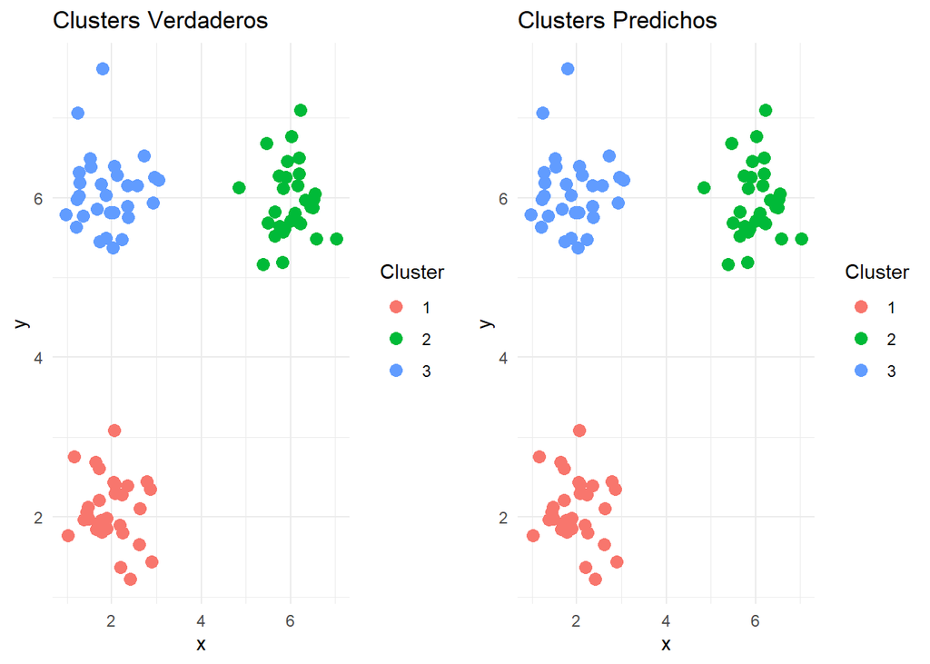

```r
# Aplicar clustering con k=3
clusters_synthetic <- cutree(hc_synthetic, k = 3)

# Comparar con clusters verdaderos
synthetic_results <- data.frame(
  x = synthetic_data$x,
  y = synthetic_data$y,
  True_Cluster = synthetic_data$true_cluster,
  Predicted_Cluster = clusters_synthetic
)

# Visualizar resultados
p1 <- ggplot(synthetic_results, aes(x = x, y = y, color = factor(True_Cluster))) +
  geom_point(size = 3) +
  labs(title = "Clusters Verdaderos", color = "Cluster") +
  theme_minimal()

p2 <- ggplot(synthetic_results, aes(x = x, y = y, color = factor(Predicted_Cluster))) +
  geom_point(size = 3) +
  labs(title = "Clusters Predichos", color = "Cluster") +
  theme_minimal()

grid.arrange(p1, p2, ncol = 2)
```

```r
# Calcular ARI
ari_synthetic <- fossil::adj.rand.index(synthetic_data$true_cluster, clusters_synthetic)
```

```
## Adjusted Rand Index (Sintéticos): 1
```

```
## Matriz de confusión:
```

```
##          Predicho
## Verdadero  1  2  3
##         1 30  0  0
##         2  0 30  0
##         3  0  0 30
```

## 11. Sensibilidad a Outliers

**¿Qué buscar en el análisis de outliers?**

- **Single linkage**: Muy sensible a outliers - puede crear cadenas artificiales
- **Complete linkage**: Más robusto - mantiene clusters compactos
- **Comparación visual**: ¿Cómo cambia la estructura del dendrograma?
- **Identificación**: Los outliers suelen aparecer como ramas separadas en el dendrograma

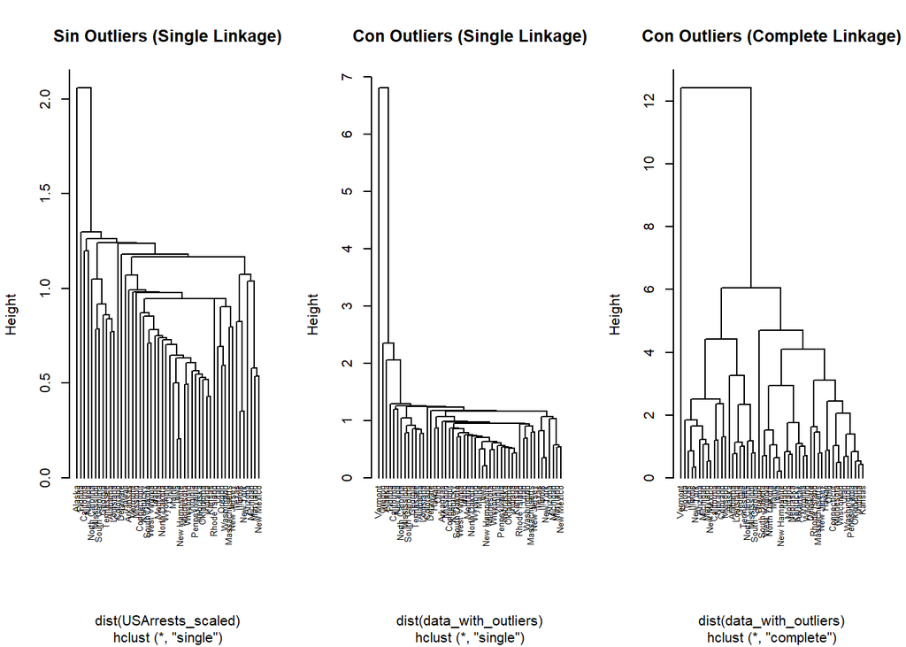

```r
# Crear datos con outliers
set.seed(456)
data_with_outliers <- USArrests_scaled
# Añadir outliers extremos
outlier_indices <- sample(nrow(data_with_outliers), 3)
data_with_outliers[outlier_indices, ] <- data_with_outliers[outlier_indices, ] * 3

# Comparar clustering con y sin outliers
hc_original <- hclust(dist(USArrests_scaled), method = "single")
hc_outliers <- hclust(dist(data_with_outliers), method = "single")

# Visualizar diferencias
par(mfrow = c(1, 3))
plot(hc_original, main = "Sin Outliers (Single Linkage)", cex = 0.6, hang = -1)
plot(hc_outliers, main = "Con Outliers (Single Linkage)", cex = 0.6, hang = -1)

# Comparar con método menos sensible a outliers
hc_complete_outliers <- hclust(dist(data_with_outliers), method = "complete")
plot(hc_complete_outliers, main = "Con Outliers (Complete Linkage)", cex = 0.6, hang = -1)
```

```r
par(mfrow = c(1, 1))
```

```
## Estados modificados como outliers:
```

```
## Vermont, Oregon, Ohio
```

## 12. Resumen y Recomendaciones

```r
# Guardar resultados finales
final_results <- data.frame(
  State = rownames(USArrests),
  Cluster = final_clusters,
  USArrests[, ]
)
```

```
## === RESUMEN EJECUTIVO ===
```

```
## NÚMERO ÓPTIMO DE CLUSTERS:
```

```
## • Gap Statistic sugiere: 4 clusters
```

```
## • Silhouette sugiere: 2 clusters
```

```
## • Elbow method sugiere: 2 clusters
```

```
## CALIDAD DEL CLUSTERING FINAL (Ward, k=4):
```

```
## • Average Silhouette Width: 0.337
```

```
## • Dunn Index: 0.16
```

```
## ESTADOS POR CLUSTER:
```

```
## Cluster 1 :
##    Alabama, Georgia, Louisiana, Mississippi, North Carolina, South Carolina, Tennessee
##
## Cluster 2 :
##    Alaska, Arizona, California, Colorado, Florida, Illinois, Maryland, Michigan, Nevada, New Mexico, New York, Texas
##
## Cluster 3 :
##    Arkansas, Connecticut, Delaware, Hawaii, Indiana, Kansas, Kentucky, Massachusetts, Missouri, New Jersey, Ohio, Oklahoma, Oregon, Pennsylvania, Rhode Island, Utah, Virginia, Washington, Wyoming
##
## Cluster 4 :
##    Idaho, Iowa, Maine, Minnesota, Montana, Nebraska, New Hampshire, North Dakota, South Dakota, Vermont, West Virginia, Wisconsin
```

## Conclusiones y Guía de Interpretación

### 📋 Checklist de Interpretación para Clustering Jerárquico

**Antes del análisis:**

- ¿Escalé las variables apropiadamente?
- ¿Verifiqué la presencia de outliers?
- ¿Las variables están en escalas comparables?

**Durante el análisis:**

- ¿Comparé múltiples métodos de enlace?
- ¿Usé varios criterios para determinar k?
- ¿Evalué diferentes medidas de distancia?

**Evaluación de resultados:**

- ¿Verifiqué la calidad con silhouette/Dunn?
- ¿Los clusters tienen interpretación sustantiva?
- ¿Los resultados son estables ante pequeños cambios?

### 🎯 Valores de Referencia

| Métrica | Excelente | Bueno | Aceptable | Problemático |
| --- | --- | --- | --- | --- |
| **Silhouette Width** | >0.7 | 0.5-0.7 | 0.25-0.5 | <0.25 |
| **Dunn Index** | >0.2 | 0.1-0.2 | 0.05-0.1 | <0.05 |
| **ARI** | >0.8 | 0.65-0.8 | 0.4-0.65 | <0.4 |

### ⚠️ Señales de Alerta

- **Muchas barras rojas** en silhouette plot
- **Clusters muy desbalanceados** en tamaño
- **ARI muy bajo** entre métodos razonables
- **Perfiles de cluster** no interpretables
- **Outliers dominando** la estructura

### ✅ Recomendaciones por Situación

**Método de Enlace:**

- **Ward**: Para clusters compactos y balanceados
- **Complete**: Buena alternativa general, robusta
- **Average**: Compromiso entre Complete y Single
- **Evitar Single**: Con presencia de outliers

**Medida de Distancia:**

- **Euclidiana**: Standard para datos continuos escalados
- **Manhattan**: Menos sensible a outliers
- **Correlación**: Cuando importan patrones vs magnitudes

**Preprocesamiento Crítico:**

- Escalado **esencial** con diferentes unidades
- Identificar y tratar outliers
- Considerar transformaciones si es necesario

### 🔍 Cuándo Usar Clustering Jerárquico vs K-means

**Usar Clustering Jerárquico cuando:**

- La jerarquía natural es importante
- No conoces el número de clusters
- Dataset pequeño-mediano (<10,000 obs)
- Quieres explorar diferentes niveles de granularidad

**Usar K-means cuando:**

- Dataset grande (>10,000 obs)
- Conoces aproximadamente k
- Eficiencia computacional es crítica
- Clusters esféricos son apropiados

### 📊 Interpretación de Este Análisis

Este notebook demuestra que el clustering jerárquico es especialmente valioso para:

- **Análisis exploratorio** donde la estructura jerárquica revela insights
- **Datasets complejos** donde el número óptimo de clusters no es obvio
- **Validación cruzada** de resultados usando múltiples criterios
- **Interpretación sustantiva** de grupos naturales en los datos

El clustering jerárquico proporciona una herramienta robusta para descubrir estructuras ocultas en datos, especialmente cuando se combina con una evaluación cuidadosa de la calidad y interpretabilidad de los resultados.

## Conclusiones

Este notebook demuestra los aspectos clave del clustering jerárquico:

- **Importancia del escalado**: Variables en diferentes escalas pueden dominar la distancia
- **Sensibilidad al método de enlace**: Single linkage es sensible a outliers, Ward produce clusters compactos
- **Selección de k**: Múltiples criterios pueden sugerir diferentes números óptimos
- **Interpretabilidad**: Los dendrogramas proporcionan insight sobre la estructura jerárquica natural
- **Validación**: Siempre evaluar la calidad usando métricas como silhouette width y Dunn index

El clustering jerárquico es especialmente valioso para análisis exploratorio donde la estructura jerárquica es importante y el número de clusters no está predeterminado.